# HW 4

Kat Aristi

2023-11-8

```r
library(tidyverse)
library(nloptr)
library(knitr)
```

## Exhaustible Resource Extraction

Suppose there is an exhaustible resource that is costlessly extracted. The inverse demand curve for the resource is $p_t=a-bq_t$ where $q_t$ is the quantity extracted in time t and a=40, b=1. The discount rate is $\delta=0.05$ and the initial stock of reserves is $R_0$ = 778.1259 units. Set up a program to find the competitive market equilibrium and show the equilibrium values of $p_t$, $q_t$, $R_t$, and $\pi_t$ in a table. $R_t$ is the reserves remaining in year t and $\pi_t$ is the discounted profits in each year (without costs, they are just equal to $\rho^tp_tq_t$ ). [Hint: it is easiest to start with the price in the last period and work backwards through time.]

### A.

List the values of $t$, $p_t$, $q_t$, $R_t$, and $\pi_t$ in a table below. What should be the final (year T) values of $p_T$ and $R_T$? Why? Does the resource get more scarce over time? What is your evidence?

**In the final year T=36, $p_t$=40, and $R_t$=0. Since these reserves contain an exhaustible resource, they will eventually end up being depleted and reach 0, which in this case occurs at year 36 due to the current set parameters. Therefore, the reserves and quantity slowly decrease as time increases. When reserves and quantity reach 0, profits will also be 0 since there is nothing left to make money off of.** **

```r
exhaust <- function( T, a, b, c, delta, R0){

  t=seq(0,T)

  price <- vector(mode="numeric", length = length(t))
  quantity <- vector(mode="numeric", length = length(t))
  reserves <- vector(mode="numeric", length = length(t))
  profits <- vector(mode="numeric", length = length(t))

  price[T+1] = a
  reserves[1] = R0

  for(i in (T + 1):2){

    quantity[i] = (a-price[i])/b
    price[i-1] = (price[i] + c*delta)/(1+delta)

  }

  quantity[1] = (a-price[1])/b
  profits[1] = price[1] * quantity[1]

  for(i in 2:(T+1)){

    reserves[i] = reserves[i-1] - quantity[i-1]
    profits[i] = 1/(1+delta) * price[i] * quantity[i]

  }

  return(data.frame("Time" = t, "Price"=price, "Quantity"=quantity, "Reserves" = reserves, "Profits" = profits))

}

table1a <- exhaust(T= 36, a= 40, b= 1, delta = 0.05, R0= 778.1259, c=0)
kable(table1a)
```

| Time | Price | Quantity | Reserves | Profits |
| --- | --- | --- | --- | --- |
| 0 | 6.906297 | 33.093703 | 778.1259000 | 228.55493 |
| 1 | 7.251611 | 32.748389 | 745.0321966 | 226.17008 |
| 2 | 7.614192 | 32.385808 | 712.2838080 | 234.84930 |
| 3 | 7.994902 | 32.005098 | 679.8980000 | 243.69296 |
| 4 | 8.394647 | 31.605353 | 647.8929016 | 252.68169 |
| 5 | 8.814379 | 31.185621 | 616.2875482 | 261.79227 |
| 6 | 9.255098 | 30.744902 | 585.1019272 | 270.99722 |
| 7 | 9.717853 | 30.282147 | 554.3570252 | 280.26424 |
| 8 | 10.203746 | 29.796254 | 524.0748780 | 289.55562 |
| 9 | 10.713933 | 29.286067 | 494.2786235 | 298.82758 |
| 10 | 11.249629 | 28.750371 | 464.9925563 | 308.02954 |
| 11 | 11.812111 | 28.187889 | 436.2421857 | 317.10331 |
| 12 | 12.402716 | 27.597284 | 408.0542965 | 325.98217 |
| 13 | 13.022852 | 26.977148 | 380.4570129 | 334.58991 |
| 14 | 13.673995 | 26.326005 | 353.4798652 | 342.83967 |
| 15 | 14.357695 | 25.642305 | 327.1538600 | 350.63275 |
| 16 | 15.075579 | 24.924421 | 301.5115546 | 357.85722 |
| 17 | 15.829358 | 24.170642 | 276.5871339 | 364.38643 |
| 18 | 16.620826 | 23.379174 | 252.4164922 | 370.07732 |
| 19 | 17.451867 | 22.548133 | 229.0373184 | 374.76859 |
| 20 | 18.324461 | 21.675539 | 206.4891859 | 378.27864 |
| 21 | 19.240684 | 20.759316 | 184.8136468 | 380.40328 |
| 22 | 20.202718 | 19.797282 | 164.0543307 | 380.91324 |
| 23 | 21.212854 | 18.787146 | 144.2570488 | 379.55141 |
| 24 | 22.273497 | 17.726503 | 125.4699028 | 376.02973 |
| 25 | 23.387172 | 16.612828 | 107.7433996 | 370.02578 |
| 26 | 24.556530 | 15.443470 | 91.1305711 | 361.17908 |
| 27 | 25.784357 | 14.215643 | 75.6871013 | 349.08687 |
| 28 | 27.073574 | 12.926426 | 61.4714579 | 333.29957 |
| 29 | 28.427253 | 11.572747 | 48.5450324 | 313.31562 |
| 30 | 29.848616 | 10.151384 | 36.9722856 | 288.57597 |
| 31 | 31.341047 | 8.658953 | 26.8209015 | 258.45777 |
| 32 | 32.908099 | 7.091901 | 18.1619481 | 222.26760 |
| 33 | 34.553504 | 5.446496 | 11.0700471 | 179.23383 |
| 34 | 36.281179 | 3.718821 | 5.6235511 | 128.49829 |
| 35 | 38.095238 | 1.904762 | 1.9047302 | 69.10701 |
| 36 | 40.000000 | 0.000000 | -0.0000317 | 0.00000 |

### B.

Now consider extensions of the model in A. First, assume there is a constant marginal cost of extraction c = 3.178025. The discount profits in each year are now $\pi_t=\rho^t (p_t-c)q_t$. Second, assume marginal costs are zero again but the initial stock of reserves increases to $R_0$ = 948.2253 units. Third, assume marginal costs are still zero and reserves go back to $R_0$=778.1259, but the demand curve parameters are now $a$=40, $b$=0.75194. A lower value of $b$ means that the demand curve rotates outward around $a$=40.

List the values of $t$, $p_t$, $q_t$, $R_t$, and $\pi_t$ for the three cases.

**See tables below!**

Case 1:

```r
exhaust_case1 <- function( T, a, b, c, delta, R0){

  t=seq(0,T)

  price <- vector(mode="numeric", length = length(t))
  quantity <- vector(mode="numeric", length = length(t))
  reserves <- vector(mode="numeric", length = length(t))
  profits <- vector(mode="numeric", length = length(t))

  price[T+1] = a
  reserves[1] = R0

  for(i in (T + 1):2){

    quantity[i] = (a-price[i])/b
    price[i-1] = (price[i] + c*delta)/(1+delta)
  }

  quantity[1] = (a-price[1])/b
  profits[1] =  delta^t * (price[1] - c) * quantity[1]

  for(i in 2:(T+1)){

    reserves[i] = reserves[i-1] - quantity[i-1]
    profits[i] = delta^t * price[i] * quantity[i]

  }

  return(data.frame("Time" = t, "Price"=price, "Quantity"=quantity, "Reserves" = reserves, "Profits" = profits))

}

table1b_case1 <- exhaust_case1(T= 38, a= 40, b= 1, delta = 0.05, R0= 778.1259, c=3.178025)
kable(table1b_case1)
```

| Time | Price | Quantity | Reserves | Profits |
| --- | --- | --- | --- | --- |
| 0 | 8.944544 | 31.055456 | 778.1259000 | 179.08187 |
| 1 | 9.232870 | 30.767130 | 747.0704438 | 284.06891 |
| 2 | 9.535612 | 30.464388 | 716.3033136 | 290.49658 |
| 3 | 9.853491 | 30.146509 | 685.8389256 | 297.04836 |
| 4 | 10.187265 | 29.812735 | 655.6924170 | 303.71023 |
| 5 | 10.537727 | 29.462273 | 625.8796816 | 310.46538 |
| 6 | 10.905712 | 29.094288 | 596.4174083 | 317.29392 |
| 7 | 11.292096 | 28.707904 | 567.3231200 | 324.17241 |
| 8 | 11.697800 | 28.302200 | 538.6152161 | 331.07347 |
| 9 | 12.123788 | 27.876212 | 510.3130157 | 337.96529 |
| 10 | 12.571077 | 27.428923 | 482.4368041 | 344.81110 |
| 11 | 13.040729 | 26.959271 | 455.0078806 | 351.56855 |
| 12 | 13.533864 | 26.466136 | 428.0486097 | 358.18909 |
| 13 | 14.051656 | 25.948344 | 401.5824740 | 364.61721 |
| 14 | 14.595338 | 25.404662 | 375.6341303 | 370.78963 |
| 15 | 15.166203 | 24.833796 | 350.2294682 | 376.63441 |
| 16 | 15.765612 | 24.234388 | 325.3956716 | 382.06996 |
| 17 | 16.394992 | 23.605008 | 301.1612840 | 387.00392 |
| 18 | 17.055840 | 22.944160 | 277.5562758 | 391.33192 |
| 19 | 17.749731 | 22.250269 | 254.6121159 | 394.93629 |
| 20 | 18.478316 | 21.521684 | 232.3618468 | 397.68448 |
| 21 | 19.243331 | 20.756669 | 210.8401630 | 399.42745 |
| 22 | 20.046596 | 19.953404 | 190.0834937 | 399.99783 |
| 23 | 20.890025 | 19.109975 | 170.1300897 | 399.20786 |
| 24 | 21.775624 | 18.224376 | 151.0201143 | 396.84716 |
| 25 | 22.705504 | 17.294496 | 132.7957388 | 392.68025 |
| 26 | 23.681878 | 16.318122 | 115.5012433 | 386.44377 |
| 27 | 24.707071 | 15.292929 | 99.1831218 | 377.84348 |
| 28 | 25.783524 | 14.216477 | 83.8901930 | 366.55086 |
| 29 | 26.913798 | 13.086202 | 69.6737165 | 352.19939 |
| 30 | 28.100587 | 11.899413 | 56.5875148 | 334.38049 |
| 31 | 29.346715 | 10.653285 | 44.6881019 | 312.63892 |
| 32 | 30.655150 | 9.344850 | 34.0348171 | 286.46779 |
| 33 | 32.029006 | 7.970994 | 24.6899668 | 255.30302 |
| 34 | 33.471555 | 6.528445 | 16.7189727 | 218.51721 |
| 35 | 34.986232 | 5.013769 | 10.1905276 | 175.41287 |
| 36 | 36.576642 | 3.423358 | 5.1767591 | 125.21495 |
| 37 | 38.246573 | 1.753427 | 1.7534009 | 67.06259 |
| 38 | 40.000000 | 0.000000 | -0.0000265 | 0.00000 |

Case 2:

```r
table1b_case2 <- exhaust_case1(T= 41, a= 40, b= 1, delta = 0.05, R0= 948.2253, c=0)
kable(table1b_case2)
```

| Time | Price | Quantity | Reserves | Profits |
| --- | --- | --- | --- | --- |
| 0 | 5.411264 | 34.588736 | 948.2253000 | 187.16878 |
| 1 | 5.681827 | 34.318173 | 913.6365641 | 194.98993 |
| 2 | 5.965919 | 34.034081 | 879.3183914 | 203.04456 |
| 3 | 6.264215 | 33.735785 | 845.2843100 | 211.32820 |
| 4 | 6.577425 | 33.422575 | 811.5485246 | 219.83449 |
| 5 | 6.906297 | 33.093703 | 778.1259499 | 228.55493 |
| 6 | 7.251611 | 32.748389 | 745.0322465 | 237.47859 |
| 7 | 7.614192 | 32.385808 | 712.2838579 | 246.59176 |
| 8 | 7.994902 | 32.005098 | 679.8980499 | 255.87761 |
| 9 | 8.394647 | 31.605353 | 647.8929515 | 265.31577 |
| 10 | 8.814379 | 31.185621 | 616.2875982 | 274.88188 |
| 11 | 9.255098 | 30.744902 | 585.1019772 | 284.54708 |
| 12 | 9.717853 | 30.282147 | 554.3570751 | 294.27745 |
| 13 | 10.203746 | 29.796254 | 524.0749280 | 304.03340 |
| 14 | 10.713933 | 29.286067 | 494.2786734 | 313.76896 |
| 15 | 11.249629 | 28.750371 | 464.9926062 | 323.43101 |
| 16 | 11.812111 | 28.187889 | 436.2422356 | 332.95847 |
| 17 | 12.402716 | 27.597284 | 408.0543465 | 342.28128 |
| 18 | 13.022852 | 26.977148 | 380.4570629 | 351.31941 |
| 19 | 13.673995 | 26.326005 | 353.4799151 | 359.98166 |
| 20 | 14.357695 | 25.642305 | 327.1539100 | 368.16439 |
| 21 | 15.075579 | 24.924421 | 301.5116045 | 375.75008 |
| 22 | 15.829358 | 24.170642 | 276.5871839 | 382.60575 |
| 23 | 16.620826 | 23.379174 | 252.4165421 | 388.58118 |
| 24 | 17.451867 | 22.548133 | 229.0373683 | 393.50702 |
| 25 | 18.324461 | 21.675539 | 206.4892358 | 397.19257 |
| 26 | 19.240684 | 20.759316 | 184.8136967 | 399.42344 |
| 27 | 20.202718 | 19.797282 | 164.0543806 | 399.95891 |
| 28 | 21.212854 | 18.787146 | 144.2570988 | 398.52899 |
| 29 | 22.273497 | 17.726503 | 125.4699528 | 394.83121 |
| 30 | 23.387172 | 16.612828 | 107.7434495 | 388.52707 |
| 31 | 24.556530 | 15.443470 | 91.1306211 | 379.23803 |
| 32 | 25.784357 | 14.215643 | 75.6871512 | 366.54122 |
| 33 | 27.073574 | 12.926426 | 61.4715079 | 349.96454 |
| 34 | 28.427253 | 11.572747 | 48.5450824 | 328.98140 |
| 35 | 29.848616 | 10.151384 | 36.9723356 | 303.00477 |
| 36 | 31.341047 | 8.658953 | 26.8209514 | 271.38066 |
| 37 | 32.908099 | 7.091901 | 18.1619981 | 233.38098 |
| 38 | 34.553504 | 5.446496 | 11.0700971 | 188.19552 |
| 39 | 36.281179 | 3.718821 | 5.6236010 | 134.92321 |
| 40 | 38.095238 | 1.904762 | 1.9047802 | 72.56236 |
| 41 | 40.000000 | 0.000000 | 0.0000182 | 0.00000 |

Case 3:

```r
table1b_case3 <- exhaust_case1(T= 30, a= 40, b= 0.75194, delta = 0.05, R0= 778.1259, c=0)
kable(table1b_case3)
```

| Time | Price | Quantity | Reserves | Profits |
| --- | --- | --- | --- | --- |
| 0 | 9.255098 | 40.887441 | 778.1259000 | 378.4173 |
| 1 | 9.717853 | 40.272026 | 737.2384594 | 391.3576 |
| 2 | 10.203746 | 39.625841 | 696.9664335 | 404.3320 |
| 3 | 10.713933 | 38.947346 | 657.3405930 | 417.2792 |
| 4 | 11.249629 | 38.234927 | 618.3932472 | 430.1288 |
| 5 | 11.812111 | 37.486886 | 580.1583207 | 442.7993 |
| 6 | 12.402716 | 36.701444 | 542.6714346 | 455.1976 |
| 7 | 13.022852 | 35.876729 | 505.9699909 | 467.2173 |
| 8 | 13.673995 | 35.010779 | 470.0932617 | 478.7372 |
| 9 | 14.357695 | 34.101531 | 435.0824827 | 489.6194 |
| 10 | 15.075579 | 33.146821 | 400.9809514 | 499.7075 |
| 11 | 15.829358 | 32.144376 | 367.8341303 | 508.8248 |
| 12 | 16.620826 | 31.091808 | 335.6897548 | 516.7715 |
| 13 | 17.451867 | 29.986611 | 304.5979472 | 523.3224 |
| 14 | 18.324461 | 28.826155 | 274.6113359 | 528.2238 |
| 15 | 19.240684 | 27.607676 | 245.7851807 | 531.1906 |
| 16 | 20.202718 | 26.328273 | 218.1775045 | 531.9027 |
| 17 | 21.212854 | 24.984900 | 191.8492311 | 530.0010 |
| 18 | 22.273497 | 23.574359 | 166.8643307 | 525.0834 |
| 19 | 23.387172 | 22.093290 | 143.2899721 | 516.6996 |
| 20 | 24.556530 | 20.538168 | 121.1966821 | 504.3461 |
| 21 | 25.784357 | 18.905289 | 100.6585144 | 487.4607 |
| 22 | 27.073574 | 17.190767 | 81.7532249 | 465.4155 |
| 23 | 28.427253 | 15.390519 | 64.5624577 | 437.5102 |
| 24 | 29.848616 | 13.500258 | 49.1719388 | 402.9640 |
| 25 | 31.341047 | 11.515484 | 35.6716806 | 360.9073 |
| 26 | 32.908099 | 9.431472 | 24.1561962 | 310.3718 |
| 27 | 34.553504 | 7.243259 | 14.7247242 | 250.2800 |
| 28 | 36.281179 | 4.945635 | 7.4814654 | 179.4335 |
| 29 | 38.095238 | 2.533130 | 2.5358303 | 96.5002 |
| 30 | 40.000000 | 0.000000 | 0.0027001 | 0.0000 |

### C.

What is the final year $T$ for the three cases? Explain why they are different from part A.

```r
cases <- 1:3
T <- c(38, 41, 30)
one_c <- data.frame('Cases' = cases, 'Time' = T)
kable(one_c)
```

| Cases | Time |
| --- | --- |
| 1 | 38 |
| 2 | 41 |
| 3 | 30 |

### D.

Compare the path of prices in the three cases to that in part A. Explain the differences.

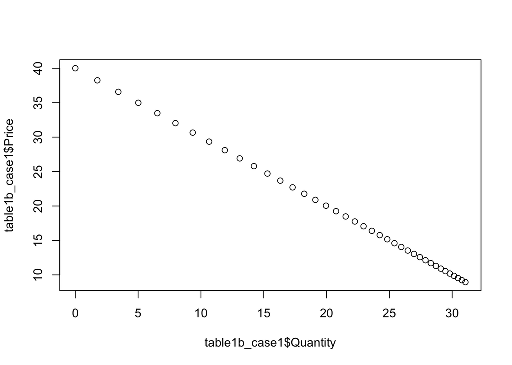

```r
plot(table1b_case1$Quantity, table1b_case1$Price)
```

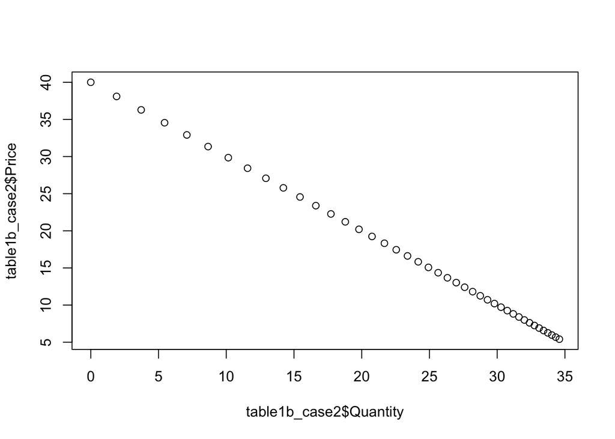

```r
plot(table1b_case2$Quantity, table1b_case2$Price)
```

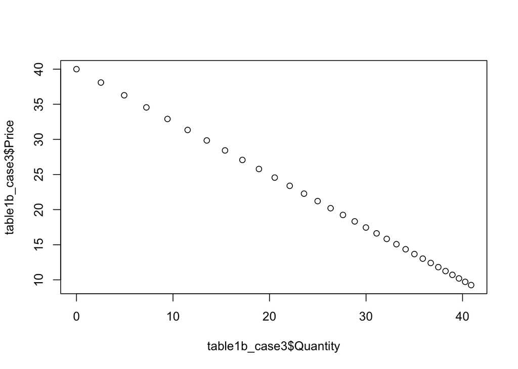

```r
plot(table1b_case3$Quantity, table1b_case3$Price)
```

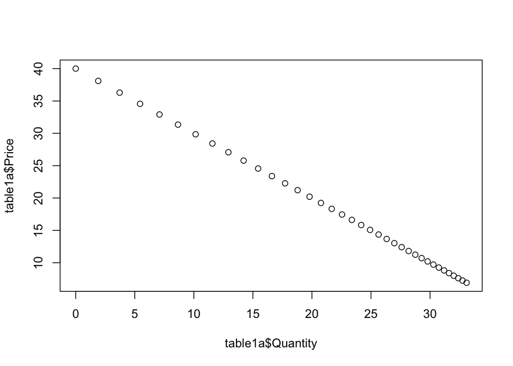

```r
plot(table1a$Quantity, table1a$Price)
```

### E.

What happens to the present discounted value of profits (in other words, the value of the reserves $R_0$) in the three cases compared to part A? Explain the differences.

**Across all cases, the profits are increasing. The cases have some profit when initially starting in time 0 due to the fact that there are already exhaustible resources in the reserve that are ready to be extracted and sold. PVNB for Case 1 and 2 are the slightly larger than part A due to the time spans being longer, which allows for a longer amount of time for the profits to increase. Case 3 is the largest because the initial price is the largest causing profits to increase. As the profits decrease, they decrease at a much sharper rate than they increase due to the because the exhaustible resource cannot renew itself so is growing smaller at a fast rate. This is further seen as an increase in prices in an attempt to increase profits, but the reserves continue to decline.**

```r
c1 <- sum(table1b_case1$Profits)
c2 <- sum(table1b_case2$Profits)
c3 <- sum(table1b_case3$Profits)

question1a <- sum(table1a$Profits)

number <- c("1A", 'Case 1', 'Case 2', 'Case 3')
PVNB <- c(question1a, c1, c2, c3)

question1e <- data.frame("Case" = number, 'PVNB' = PVNB)

kable(question1e)
```

| Case | PVNB |
| --- | --- |
| 1A | 10801.88 |
| Case 1 | 12341.21 |
| Case 2 | 12346.91 |
| Case 3 | 13062.00 |